# R Notebook

# Exercise 1

## 1) Data Import via SQLite

```r
library(RSQLite)
setwd("C:/Users/Burcu Kolbay/Downloads")
sqlite <- dbDriver("SQLite")
conn <- dbConnect(sqlite, "ex1.db")
dbListTables(conn)
```

```
## [1] "holiday" "stock"   "tbl1"
```

```r
# extracting tables through the connection created
holiday <- dbGetQuery(conn, "select * from holiday")
stock <- dbGetQuery(conn, "select * from stock")
```

```r
library(dplyr)
glimpse(stock)
```

```
## Observations: 7,056
## Variables: 7
## $ index          <int> 0, 1, 2, 3, 4, 5, 6, 7, 8, 9, 10, 11, 12, 13, 1...
## $ date           <chr> "1990-01-02", "1990-01-03", "1990-01-04", "1990...
## $ close_msft     <dbl> 0.616319, 0.619792, 0.638021, 0.622396, 0.63194...
## $ close_orcl     <dbl> 0.595679, 0.530864, 0.546296, 0.515432, 0.53395...
## $ close_appl     <dbl> 1.330357, 1.339286, 1.343750, 1.348214, 1.35714...
## $ close_dowjones <dbl> 2810.15, 2809.73, 2796.08, 2773.25, 2794.37, 27...
## $ close_nasdaq   <dbl> 459.3, 460.9, 459.4, 458.2, 458.7, 456.8, 450.7...
```

```r
glimpse(holiday)
```

```
## Observations: 10,228
## Variables: 5
## $ index <int> 0, 1, 2, 3, 4, 5, 6, 7, 8, 9, 10, 11, 12, 13, 14, 15, 16...
## $ date  <chr> "1990-01-01", "1990-01-02", "1990-01-03", "1990-01-04", ...
## $ usa   <chr> "New Year's Day", NA, NA, NA, NA, NA, NA, NA, NA, NA, NA...
## $ uk    <chr> "New Year's Day", NA, NA, NA, NA, NA, NA, NA, NA, NA, NA...
## $ japan <chr> "元日", NA, NA, NA, NA, NA, NA, NA, NA, NA, NA, NA, NA, NA...
```

## 2) Data Merge

The “stock” and “holiday” data sets are merged by “date” column, and it is named as “whole_data_set”.

```r
whole_data_set <- merge(stock, holiday, by="date")
glimpse(whole_data_set)
```

```
## Observations: 7,056
## Variables: 11
## $ date           <chr> "1990-01-02", "1990-01-03", "1990-01-04", "1990...
## $ index.x        <int> 0, 1, 2, 3, 4, 5, 6, 7, 8, 9, 10, 11, 12, 13, 1...
## $ close_msft     <dbl> 0.616319, 0.619792, 0.638021, 0.622396, 0.63194...
## $ close_orcl     <dbl> 0.595679, 0.530864, 0.546296, 0.515432, 0.53395...
## $ close_appl     <dbl> 1.330357, 1.339286, 1.343750, 1.348214, 1.35714...
## $ close_dowjones <dbl> 2810.15, 2809.73, 2796.08, 2773.25, 2794.37, 27...
## $ close_nasdaq   <dbl> 459.3, 460.9, 459.4, 458.2, 458.7, 456.8, 450.7...
## $ index.y        <int> 1, 2, 3, 4, 7, 8, 9, 10, 11, 14, 15, 16, 17, 18...
## $ usa            <chr> NA, NA, NA, NA, NA, NA, NA, NA, NA, "Martin Lut...
## $ uk             <chr> NA, NA, NA, NA, NA, NA, NA, NA, NA, NA, NA, NA,...
## $ japan          <chr> NA, NA, NA, NA, NA, NA, NA, NA, NA, "成人の日", NA,...
```

In “whole_data_set”, the “index.x” and “index.y” attributes are removed.

```r
whole_data_set <- whole_data_set[,-c(2,8)]
whole_data_set$date <- as.Date(whole_data_set$date)
```

## 3) Data Type Convertions

The “usa”, “uk” and “japan” attributes are binarized. If there is any input in the cell it takes $1$, otherwise $0$.

```r
names(whole_data_set)
```

```
## [1] "date"           "close_msft"     "close_orcl"     "close_appl"
## [5] "close_dowjones" "close_nasdaq"   "usa"            "uk"
## [9] "japan"
```

```r
binarizing <- function(x) {
  x_country <- x[, c(7:9)]
  x_country[!is.na(x_country)] <- 1
  x_country[is.na(x_country)] <- 0
  x_holiday <- cbind(x[, c(1:6)], x_country)
  return(x_holiday)
}

whole_data_set <- binarizing(whole_data_set)
glimpse(whole_data_set)
```

```
## Observations: 7,056
## Variables: 9
## $ date           <date> 1990-01-02, 1990-01-03, 1990-01-04, 1990-01-05...
## $ close_msft     <dbl> 0.616319, 0.619792, 0.638021, 0.622396, 0.63194...
## $ close_orcl     <dbl> 0.595679, 0.530864, 0.546296, 0.515432, 0.53395...
## $ close_appl     <dbl> 1.330357, 1.339286, 1.343750, 1.348214, 1.35714...
## $ close_dowjones <dbl> 2810.15, 2809.73, 2796.08, 2773.25, 2794.37, 27...
## $ close_nasdaq   <dbl> 459.3, 460.9, 459.4, 458.2, 458.7, 456.8, 450.7...
## $ usa            <chr> "0", "0", "0", "0", "0", "0", "0", "0", "0", "1...
## $ uk             <chr> "0", "0", "0", "0", "0", "0", "0", "0", "0", "0...
## $ japan          <chr> "0", "0", "0", "0", "0", "0", "0", "0", "0", "1...
```

The “usa”, “uk” and “japan” attributes’ classes are converted into the factor type.

```r
shouldBeFactor <- c('usa', 'uk', 'japan')
for(v in shouldBeFactor) {
  whole_data_set[[v]] <- as.factor(whole_data_set[[v]])
}
glimpse(whole_data_set)
```

```
## Observations: 7,056
## Variables: 9
## $ date           <date> 1990-01-02, 1990-01-03, 1990-01-04, 1990-01-05...
## $ close_msft     <dbl> 0.616319, 0.619792, 0.638021, 0.622396, 0.63194...
## $ close_orcl     <dbl> 0.595679, 0.530864, 0.546296, 0.515432, 0.53395...
## $ close_appl     <dbl> 1.330357, 1.339286, 1.343750, 1.348214, 1.35714...
## $ close_dowjones <dbl> 2810.15, 2809.73, 2796.08, 2773.25, 2794.37, 27...
## $ close_nasdaq   <dbl> 459.3, 460.9, 459.4, 458.2, 458.7, 456.8, 450.7...
## $ usa            <fct> 0, 0, 0, 0, 0, 0, 0, 0, 0, 1, 0, 0, 0, 0, 0, 0,...
## $ uk             <fct> 0, 0, 0, 0, 0, 0, 0, 0, 0, 0, 0, 0, 0, 0, 0, 0,...
## $ japan          <fct> 0, 0, 0, 0, 0, 0, 0, 0, 0, 1, 0, 0, 0, 0, 0, 0,...
```

## 4) Descriptive Statistics

```r
summary(whole_data_set)
```

```
##       date              close_msft        close_orcl
##  Min.   :1990-01-02   Min.   : 0.5981   Min.   : 0.1327
##  1st Qu.:1996-12-19   1st Qu.:10.3281   1st Qu.: 4.1528
##  Median :2003-12-25   Median :26.7200   Median :13.8400
##  Mean   :2003-12-27   Mean   :25.7149   Mean   :17.6312
##  3rd Qu.:2010-12-28   3rd Qu.:32.8963   3rd Qu.:30.1925
##  Max.   :2017-12-29   Max.   :86.8500   Max.   :52.8000
##    close_appl       close_dowjones   close_nasdaq    usa      uk
##  Min.   :  0.4621   Min.   : 2365   Min.   : 325.4   0:6988   0:7055
##  1st Qu.:  1.3839   1st Qu.: 6483   1st Qu.:1245.2   1:  68   1:   1
##  Median :  3.3002   Median :10353   Median :2084.4
##  Mean   : 28.7652   Mean   :10076   Mean   :2321.5
##  3rd Qu.: 46.2307   3rd Qu.:12566   3rd Qu.:2853.4
##  Max.   :176.4200   Max.   :24838   Max.   :6994.8
##  japan
##  0:6722
##  1: 334
##
##
##
##
```

```r
library(reshape)
```

```r
library(ggplot2)
plot_sets<-whole_data_set[,c(2:6)]
meltData <- melt(plot_sets)
```

```
## Using  as id variables
```

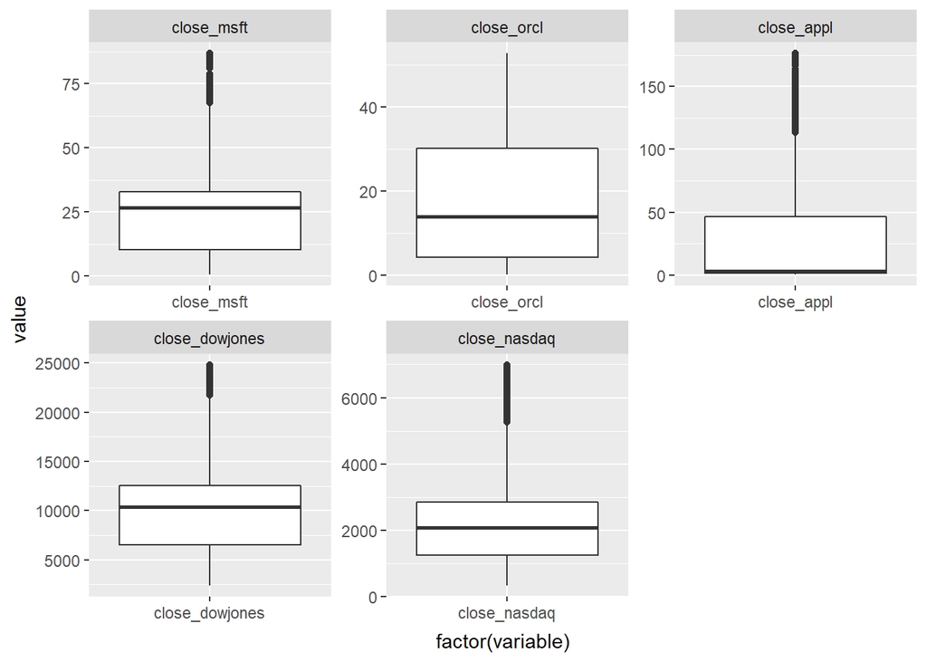

```r
p <- ggplot(meltData, aes(factor(variable), value))
p + geom_boxplot() + facet_wrap(~variable, scale="free")
```

```r
library(tidyr)
```

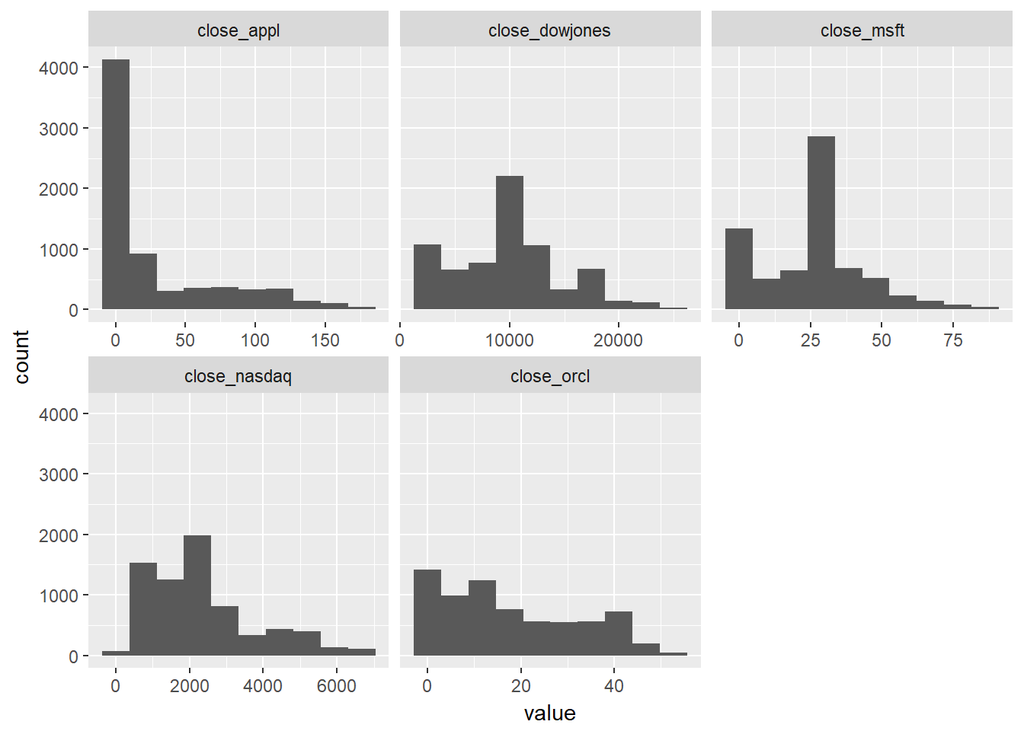

```r
ggplot(gather(plot_sets), aes(value)) + geom_histogram(bins=10) + facet_wrap(~key, scales="free_x")
```

```r
table(whole_data_set$usa)
```

```
##
##    0    1
## 6988   68
```

```r
table(whole_data_set$uk)
```

```
##
##    0    1
## 7055    1
```

```r
table(whole_data_set$japan)
```

```
##
##    0    1
## 6722  334
```

Microsoft stock prices:

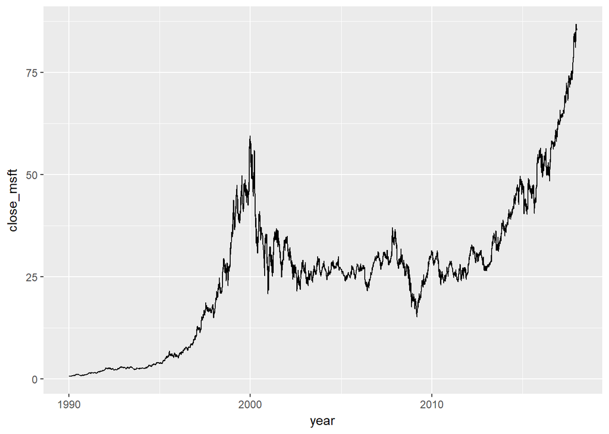

```r
library(ggplot2)
ggplot(whole_data_set, aes(date, close_msft)) + geom_line() + scale_x_date('year')
```

Here we can see that stock prices of Microsoft was low at the first half of the 90s, but then it started to increase. It had a peak in 2000. It had some peaks between 2000 and 2010, however it never reached the price it had in 2000. Just before 2010, it has a drop in the prices again. After 2010, it has started to increase, and it reached the highest price.

Apple stock prices:

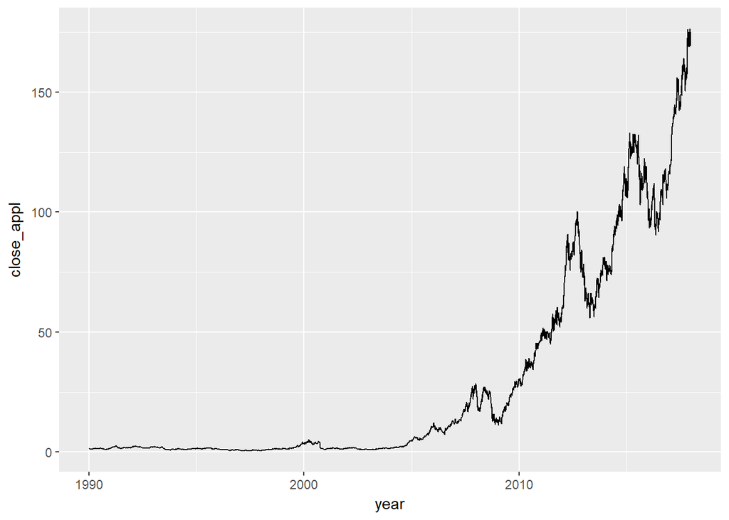

```r
ggplot(whole_data_set, aes(date, close_appl)) + geom_line() + scale_x_date('year')
```

In the plot above, it is easy to realize that Apple’s stock prices were really low until 2005. After 2005, it has started to increase. Sometime it has some drops, however it kept on increasing. If we compare it with Microsoft, we can realize that its value at the end of the data time is doubled Microsoft.

Oracle stock prices:

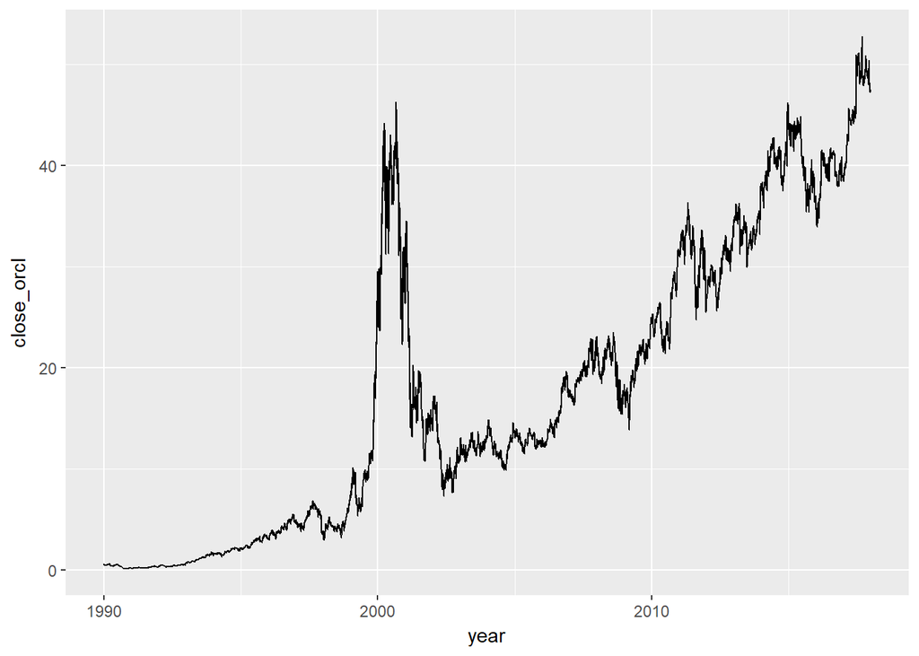

```r
ggplot(whole_data_set, aes(date, close_orcl)) + geom_line() + scale_x_date('year')
```

The plot above shows us that Oracle had an amazing peak between 2000 and 2002, and it is kind of similar to Microsoft. However, after that, it had a significant drop. The prices were trying to go back to the level of 2000 until the end of the data time. Recently, the prices came to the same level with 2000 and passed it little bit.

```r
cor(plot_sets)
```

```
##                close_msft close_orcl close_appl close_dowjones
## close_msft      1.0000000  0.8392389  0.7348832      0.9373436
## close_orcl      0.8392389  1.0000000  0.8473892      0.9132100
## close_appl      0.7348832  0.8473892  1.0000000      0.8365677
## close_dowjones  0.9373436  0.9132100  0.8365677      1.0000000
## close_nasdaq    0.9389987  0.9347680  0.8667130      0.9558089
##                close_nasdaq
## close_msft        0.9389987
## close_orcl        0.9347680
## close_appl        0.8667130
## close_dowjones    0.9558089
## close_nasdaq      1.0000000
```

The correlation between “close_dowjones” and “close_nasdaq” is the highest correlation.

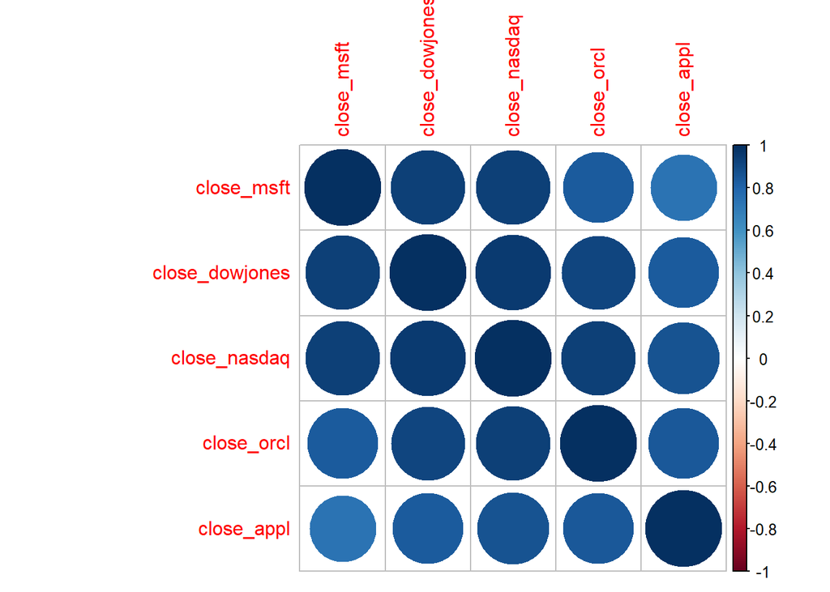

```r
library(corrplot)
corrplot(cor(plot_sets), order = "hclust")
```

Since the lowest correlation value is 73%, our correlation plot’s color sticks to blue.

## 5) close_msft Part

```r
cor(plot_sets)
```

```
##                close_msft close_orcl close_appl close_dowjones
## close_msft      1.0000000  0.8392389  0.7348832      0.9373436
## close_orcl      0.8392389  1.0000000  0.8473892      0.9132100
## close_appl      0.7348832  0.8473892  1.0000000      0.8365677
## close_dowjones  0.9373436  0.9132100  0.8365677      1.0000000
## close_nasdaq    0.9389987  0.9347680  0.8667130      0.9558089
##                close_nasdaq
## close_msft        0.9389987
## close_orcl        0.9347680
## close_appl        0.8667130
## close_dowjones    0.9558089
## close_nasdaq      1.0000000
```

There is a high correlation between “close_dowjones” and “close_nasdaq” (more than 95% - higher than the other pairs). Thus, “close_nasdaq” is removed.

```r
whole_data_set1 <- whole_data_set[, -6]
```

As we can see “uk” does not have any effect because of its distribution.

```r
whole_data_set1 <- whole_data_set1[,-7]
```

```r
library(randomForest)
rf <- randomForest(close_msft~., data = whole_data_set1[,-1], ntree=100, keep.forest=F, importance=T)
importance(rf)
```

```
##                   %IncMSE IncNodePurity
## close_orcl      9.2715810   569339.5707
## close_appl      9.6676396   402449.4665
## close_dowjones 11.6238027   635753.4701
## usa            -0.8257298      326.4848
## japan          -0.4510952      392.8942
```

### 5.1) ARIMA

```r
library(tseries)
dta<- ts(whole_data_set1, frequency = 7)
raw.result <- lm(close_msft ~ ., data = whole_data_set1)
adf.test(raw.result$residuals, alternative = "stationary")
```

```
##
##  Augmented Dickey-Fuller Test
##
## data:  raw.result$residuals
## Dickey-Fuller = -3.9704, Lag order = 19, p-value = 0.01042
## alternative hypothesis: stationary
```

The data is stationary.

Since we are taken the other attributes into consideration (not univariate time series), the adf.test is applied on “lm()” results.

Because of the running time for each model for each price, a small sample is used from the data. The first 60 observations is used to predict 15 observations that comes right after the first 60.

```r
train_msft <- dta[1:60,]
test_msft <- dta[61:75,]
```

The extra attributes are imported using “xreg”.

```r
library(forecast)
covariates_msft <- c("close_orcl", "close_appl", "close_dowjones","usa","japan")
fit <- auto.arima(train_msft[,"close_msft"], xreg = train_msft[, covariates_msft])
fcast <- forecast(fit, xreg = test_msft[, covariates_msft])
accuracy(fcast)
```

```
##                        ME       RMSE         MAE        MPE     MAPE
## Training set 0.0004782763 0.01046062 0.007644625 0.05401824 1.119324
##                   MASE       ACF1
## Training set 0.7530305 0.04931446
```

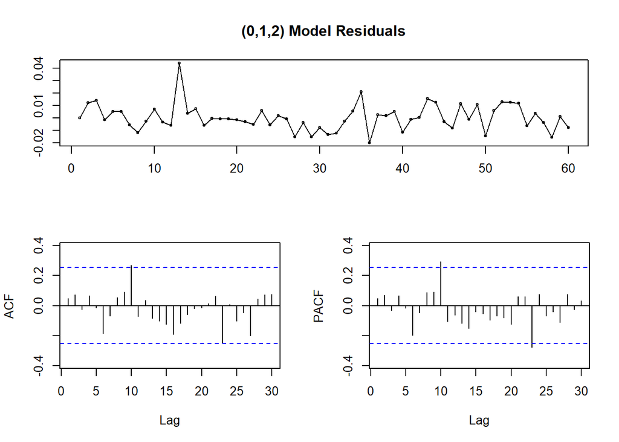

```r
tsdisplay(residuals(fit), lag.max = 30, main="(0,1,2) Model Residuals")
```

Tuning:

```r
lambda <- BoxCox.lambda(train_msft[,"close_msft"])
fit_2 <- Arima(train_msft[,"close_msft"], xreg = train_msft[, covariates_msft],  lambda = lambda, order=c(1,2,2))
fcast2 <- forecast(fit_2, xreg = test_msft[, covariates_msft])
accuracy(fcast2)
```

```
##                        ME       RMSE         MAE        MPE     MAPE
## Training set -0.001036216 0.01008923 0.007277269 -0.1835701 1.069046
##                   MASE       ACF1
## Training set 0.7168442 0.05572647
```

### 5.2) Neural Networks

```r
fit_net <- nnetar(train_msft[, "close_msft"], xreg=train_msft[, covariates_msft])
fcast_net <- forecast(fit_net, PI = TRUE, xreg=test_msft[, covariates_msft] )
accuracy(fcast_net)
```

```
##                        ME        RMSE         MAE         MPE     MAPE
## Training set 7.746568e-06 0.006027439 0.004559054 -0.01045586 0.669373
##                   MASE       ACF1
## Training set 0.4490876 -0.2495455
```

## 6) close_orcl Part

### 6.1) ARIMA

```r
covariates_orcl <- c("close_msft", "close_appl", "close_dowjones","usa","japan")
fit <- auto.arima(train_msft[,"close_orcl"], xreg = train_msft[, covariates_orcl])
fcast <- forecast(fit, xreg = test_msft[, covariates_orcl])
accuracy(fcast)
```

```
##                         ME       RMSE        MAE        MPE     MAPE
## Training set -0.0007012055 0.01557278 0.01228668 -0.2062711 2.235482
##                   MASE        ACF1
## Training set 0.7988877 -0.07504693
```

Tuning:

```r
lambda <- BoxCox.lambda(train_msft[,"close_orcl"])
fit_2 <- Arima(train_msft[,"close_orcl"], xreg = train_msft[, covariates_orcl],  lambda = lambda, order=c(1,2,2))
fcast2 <- forecast(fit_2, xreg = test_msft[, covariates_orcl])
accuracy(fcast2)
```

```
##                       ME       RMSE        MAE       MPE     MAPE
## Training set 0.003578639 0.01473546 0.01201257 0.6861307 2.185588
##                   MASE      ACF1
## Training set 0.7810653 0.1315892
```

### 6.2) Neural Networks

```r
fit_net <- nnetar(train_msft[, "close_orcl"], xreg=train_msft[, covariates_orcl])
fcast_net <- forecast(fit_net, PI = TRUE, xreg=test_msft[, covariates_orcl] )
accuracy(fcast_net)
```

```
##                        ME        RMSE         MAE         MPE      MAPE
## Training set 1.298197e-05 0.005835439 0.004145892 -0.02005878 0.7676041
##                   MASE       ACF1
## Training set 0.2695686 -0.1188425
```

## 7) close_appl

## 7.1) ARIMA

```r
covariates_apple <- c("close_msft", "close_orcl", "close_dowjones","usa","japan")
fit <- auto.arima(train_msft[,"close_appl"], xreg = train_msft[, covariates_apple])
fcast <- forecast(fit, xreg = test_msft[, covariates_apple])
accuracy(fcast)
```

```
##                        ME       RMSE        MAE        MPE     MAPE
## Training set -0.000314539 0.02949366 0.02112813 -0.1006098 1.665669
##                  MASE       ACF1
## Training set 0.906588 0.04552418
```

Tuning:

```r
lambda <- BoxCox.lambda(train_msft[,"close_appl"])
fit_2 <- Arima(train_msft[,"close_appl"], xreg = train_msft[, covariates_apple],  lambda = lambda, order=c(1,2,2))
fcast2 <- forecast(fit_2, xreg = test_msft[, covariates_apple])
accuracy(fcast2)
```

```
##                       ME       RMSE        MAE       MPE    MAPE      MASE
## Training set 0.002827865 0.02842662 0.02072685 0.1966978 1.62947 0.8893696
##                     ACF1
## Training set -0.09603305
```

### 7.2) Neural Networks

```r
fit_net <- nnetar(train_msft[, "close_appl"], xreg=train_msft[, covariates_apple])
fcast_net <- forecast(fit_net, PI = TRUE, xreg=test_msft[, covariates_apple] )
accuracy(fcast_net)
```

```
##                         ME       RMSE        MAE         MPE      MAPE
## Training set -6.731771e-06 0.01433856 0.01066149 -0.01750209 0.8592316
##                   MASE       ACF1
## Training set 0.4574745 0.00684609
```

# Conclusion:

For all target stock prices, first auto.arima is used with xreg. Then the auto.arima model is tunned using lambda value that comes from BoxCox.lambda function, which minimizes the coefficient of variation for subseries, and it is a number indicating the Box-Cox transformation parameter. This lambda value helped us to reduce the error in each model for each target stock price. “nnetar” is used as the neural network choice, and that is feed-forward neural network with a single hidden layer and lagged inputs. For all the stock prices, neural network gave the lowest error.

# Future Work:

Because of the limited time for this assignment, other neural networks and tuning step could not be applied. I would like to see the results with RNN as well. The simple models are used in order to finish the study before deadline.

For the future selection step, I would like to add a more advance selection method in order to be sure that I worked with the right attributes. The attribute selection in this study is done using only correlations information.